# Titanic Survival Analysis Project

I wish to explore the factors that may impact a passenger's survival chance on Titanic, 1) Gender, 2) Passenger class, 3) Embarkment location, 4) number of family members, and 5) Age

```python
%pylab inline
import matplotlib.pyplot as plt
import numpy as np
import pandas as pd
import seaborn as sns
import scipy.stats as sp

filename = 'C:/Users/tonyc/Desktop/Udacity/P2/Project 2/Titanic/titanic-data.csv'
titanic_df = pd.read_csv(filename)
```

```python
# This function will conduct the chi-square test of independence.
# It will output frequency table, degree of freedom, chi2 test statistic, and p-value

def compute_chi_square(x, y):
    freqtab = pd.crosstab(x, y)
    print("Frequency table")
    print("============================")
    print(freqtab)
    print("============================")
    chi2, pval, dof, expected = sp.chi2_contingency(freqtab)
    print('degree of freedom: ', dof)
    print('Chi-Square test statistic: ', chi2)
    print('p-value: ', pval)
    return
```

# Passenger Breakdown

```python
titanic_df.describe()
```

|  | PassengerId | Survived | Pclass | Age | SibSp | Parch | Fare |
| --- | --- | --- | --- | --- | --- | --- | --- |
| count | 891.000000 | 891.000000 | 891.000000 | 714.000000 | 891.000000 | 891.000000 | 891.000000 |
| mean | 446.000000 | 0.383838 | 2.308642 | 29.699118 | 0.523008 | 0.381594 | 32.204208 |
| std | 257.353842 | 0.486592 | 0.836071 | 14.526497 | 1.102743 | 0.806057 | 49.693429 |
| min | 1.000000 | 0.000000 | 1.000000 | 0.420000 | 0.000000 | 0.000000 | 0.000000 |
| 25% | 223.500000 | 0.000000 | 2.000000 | NaN | 0.000000 | 0.000000 | 7.910400 |
| 50% | 446.000000 | 0.000000 | 3.000000 | NaN | 0.000000 | 0.000000 | 14.454200 |
| 75% | 668.500000 | 1.000000 | 3.000000 | NaN | 1.000000 | 0.000000 | 31.000000 |
| max | 891.000000 | 1.000000 | 3.000000 | 80.000000 | 8.000000 | 6.000000 | 512.329200 |

So there are a total of 891 passengers on Titanic. Their average age is around 30 years old, and their average fare price is $32.20. Overall, only 38.38% of total passengers survived the crash.

```python
titanic_df.groupby('Pclass')['Fare'].mean()
```

```
Pclass
1    84.154687
2    20.662183
3    13.675550
Name: Fare, dtype: float64
```

# Data Cleaning

```python
# This cell counts the number of missing entries in each column
titanic_df.apply(lambda x: sum(x.isnull()),axis=0)
```

```
PassengerId      0
Survived         0
Pclass           0
Name             0
Sex              0
Age            177
SibSp            0
Parch            0
Ticket           0
Fare             0
Cabin          687
Embarked         2
dtype: int64
```

Here we see that 177 passengers are missing Age information, 687 of them are missing Cabin information, and only 2 of them are missing Embarked information.

```python
del titanic_df['Cabin']
del titanic_df['Ticket']
```

Because most of the Cabin information are missing, therefore I have decided to delete it. Ticket Number also gives little information since each one of them is unique, so I have decided to remove it as well. I will also remove passengers who are missing age information when analyzing age-survival correlation later, so that the data will not be tilted.

# Gender Analysis

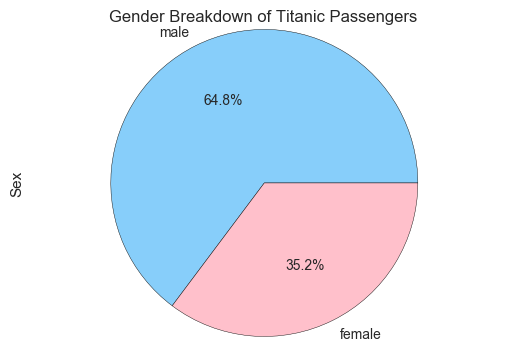

```python
# This cell examines the gender proportion of the total passengers
titanic_df['Sex'].value_counts().plot(kind='pie', autopct='%1.1f%%', colors=['lightskyblue','pink'])
plt.axis('equal')
plt.title('Gender Breakdown of Titanic Passengers');
```

From the analysis above, we find that about 2/3 of the passengers are male, and 1/3 are female.

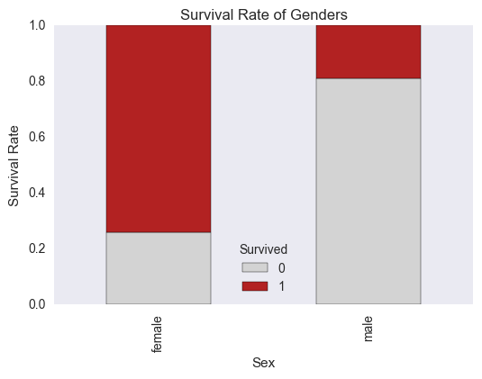

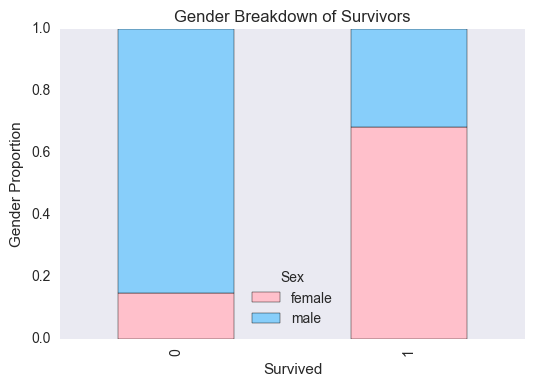

```python
# This cell examines the correlation between gender and survival

sex_survive = pd.crosstab(titanic_df['Sex'], titanic_df['Survived']).apply(lambda r: r/r.sum(), axis=1)
ax1 = sex_survive.plot(kind='bar', stacked=True, color=['lightgrey','firebrick'], grid=False, title='Survival Rate of Genders')
ax1.set_ylabel('Survival Rate');

survive_sex = pd.crosstab(titanic_df['Survived'], titanic_df['Sex']).apply(lambda r: r/r.sum(), axis=1)
ax2= survive_sex.plot(kind='bar', stacked=True, color=['pink', 'lightskyblue'], grid=False, title='Gender Breakdown of Survivors')
ax2.set_ylabel('Gender Proportion');
```

Overall 75% of the female passengers survived the accident where only around 20% of the male passengers did. This could be due to two possible reasons: 1) ladies are given the priority to board the lifeboats; 2) there are twice as many men as there are ladies, so more men were left out of the lifeboats. If that was the case, we would expect the survival proportion of the two genders to reflect the percentage of the total passengers.

Looking at the second graph we see that out of all the survived passengers, 70% of them are females and 30% are male, which do not reflect the gender proportion of the total population, so we can conclude that ladies are given the priority to board the lifeboats.

```python
compute_chi_square(titanic_df['Survived'], titanic_df['Sex'])
```

```
Frequency table
============================
Sex       female  male
Survived
0             81   468
1            233   109
============================
('degree of freedom: ', 1L)
('Chi-Square test statistic: ', 260.71702016732104)
('p-value: ', 1.1973570627755645e-58)
```

To prove there is correlation between survival and sex, I have decided to conduct a chi-squared test of independence since both variables are categorical.

H_0: Survival Rate and Sex are independent.

H_1: Survival Rate and Sex are dependent.

The p-value of the test is 1.197e-58, which is smaller than critical value 0.005, therefore null hypotheses can be rejected, and it's proven that the two variables are dependent.

# Passenger Class Analysis

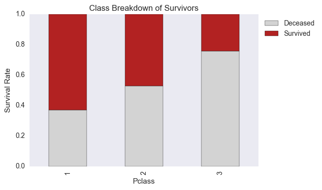

```python
# This cell examines the correlation between survival rate and passenger class grouped by gender

pclass_survive = pd.crosstab(titanic_df['Pclass'], titanic_df['Survived']).apply(lambda r: r/r.sum(), axis=1)
ax = pclass_survive.plot(kind='bar', stacked=True, color=['lightgrey','firebrick'], grid=False, title='Class Breakdown of Survivors')
ax.set_ylabel('Survival Rate')
plt.legend(('Deceased', 'Survived'), loc='upper left', prop={'size':10}, bbox_to_anchor=(1,1));
```

Looking at the above graph we can see that Class 1 passengers have a little over 60% chance of surviving, which is higher than the average of 38%. Class 2 passengers have about 50% survival rate, which is also higher than the average of 38%. Class 3 passengers' survival rate decreases to about 20%, which is much lower than average.

Therefore we can conclude that social class, assuming Passenger Class reflects social classes, is also an important factor to survival. Class 1 and 2 passengers are given priorities over Class 3 passengers.

```python
compute_chi_square(titanic_df['Survived'], titanic_df['Pclass'])
```

```
Frequency table
============================
Pclass      1   2    3
Survived
0          80  97  372
1         136  87  119
============================
('degree of freedom: ', 2L)
('Chi-Square test statistic: ', 102.88898875696056)
('p-value: ', 4.5492517112987927e-23)
```

To prove there is correlation between survival and passenger class, I have decided to conduct a chi-squared test of independence since both variables are categorical.

H_0: Survival Rate and Passenger Class are independent.

H_1: Survival Rate and Passenger Class are dependent.

The p-value of the test is 4.549e-23, which is smaller than critical value 0.005, therefore null hypotheses can be rejected, and it's proven that the two variables are dependent.

# Family Size Analysis

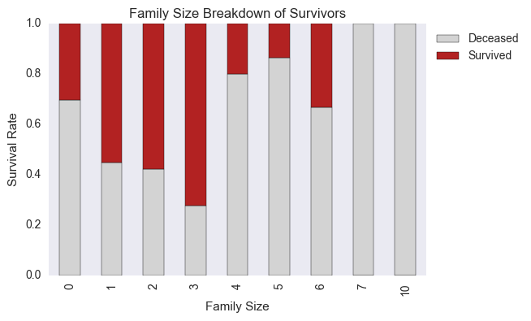

```python
# This cell examines the correlation between survival rate and the number of siblings and spouse grouped by gender.

family_survive = pd.crosstab((titanic_df['SibSp'] + titanic_df['Parch']), titanic_df['Survived']).apply(lambda r: r/r.sum(), axis=1)
ax = family_survive.plot(kind='bar', stacked=True, color=['lightgrey','firebrick'], grid=False, title='Family Size Breakdown of Survivors')
ax.set_xlabel('Family Size')
ax.set_ylabel('Survival Rate')
plt.legend(('Deceased', 'Survived'), loc='upper left', prop={'size':10}, bbox_to_anchor=(1,1));
```

I have decided to add the number of siblings/spouse with the number of parents/children as the family size.

When passengers are travelling with 1, 2, or 3 family members, their survival rates are above average between 55% and 80%. Their survival chances are on par with or below average when they are travelling alone or with more than 3 family members.

```python
compute_chi_square(titanic_df['Survived'], (titanic_df['SibSp'] + titanic_df['Parch']))
```

```
Frequency table
============================
col_0      0   1   2   3   4   5   6   7   10
Survived
0         374  72  43   8  12  19   8   6   7
1         163  89  59  21   3   3   4   0   0
============================
('degree of freedom: ', 8L)
('Chi-Square test statistic: ', 80.67231343783078)
('p-value: ', 3.579668975443533e-14)
```

To prove there is correlation between survival and family size, I have decided to conduct a chi-squared test of independence since both variables are categorical.

H_0: Survival Rate and Family Size are independent.

H_1: Survival Rate and Family Size are dependent.

The p-value of the test is 3.579e-14, which is smaller than critical value 0.005, therefore null hypotheses can be rejected, and it's proven that the two variables are dependent.

# Embarkment Analysis

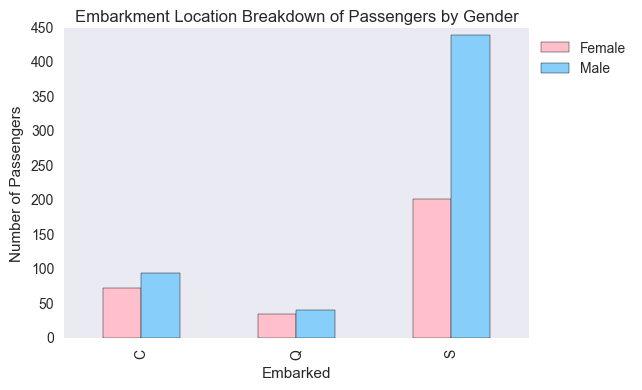

```python
# This cell examines the number of passengers embarking at each location grouped by gender.

embark_sex = pd.crosstab(titanic_df['Embarked'], titanic_df['Sex'])
ax = embark_sex.plot(kind='bar', stacked=False, color=['pink', 'lightskyblue'], grid=False, title='Embarkment Location Breakdown of Passengers by Gender')
ax.set_ylabel('Number of Passengers')
plt.legend(('Female', 'Male'), loc='upper left', prop={'size':10}, bbox_to_anchor=(1,1));
```

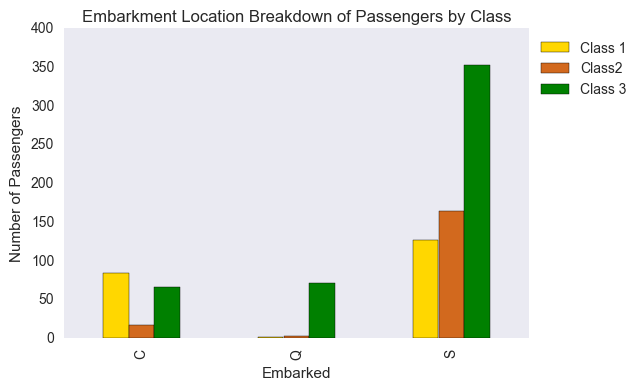

```python
embark_sex = pd.crosstab(titanic_df['Embarked'], titanic_df['Pclass'])
ax = embark_sex.plot(kind='bar', stacked=False, color=['gold', 'chocolate', 'green'], grid=False, title='Embarkment Location Breakdown of Passengers by Class')
ax.set_ylabel('Number of Passengers')
plt.legend(('Class 1', 'Class2', 'Class 3'), loc='upper left', prop={'size':10}, bbox_to_anchor=(1,1));
```

Majority of the passengers boarded on Southampton.

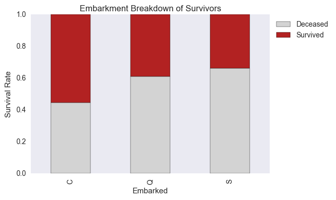

```python
# This cell examines the correlation between survival rate and the embarkment location grouped by gender.

embark_survive = pd.crosstab(titanic_df['Embarked'], titanic_df['Survived']).apply(lambda r: r/r.sum(), axis=1)
ax = embark_survive.plot(kind='bar', stacked=True, color=['lightgrey','firebrick'], grid=False, title='Embarkment Breakdown of Survivors')
ax.set_ylabel('Survival Rate')
plt.legend(('Deceased', 'Survived'), loc='upper left', prop={'size':10}, bbox_to_anchor=(1,1));
```

Embarkment location also seem to have a large impact on survival rate. If a passenger boarded at Cherbourg, his/her survival rate is high at 60%. If a passenger boarded at Queenstown or Southampton, his/her chance remains about average at 38%.

```python
compute_chi_square(titanic_df['Survived'], titanic_df['Embarked'])
```

```
Frequency table
============================
Embarked   C   Q    S
Survived
0         75  47  427
1         93  30  217
============================
('degree of freedom: ', 2L)
('Chi-Square test statistic: ', 26.489149839237619)
('p-value: ', 1.769922284120912e-06)
```

To prove there is correlation between survival and embarkment location, I have decided to conduct a chi-squared test of independence since both variables are categorical.

H_0: Survival Rate and Embarkment Location are independent.

H_1: Survival Rate and Embarkment Location are dependent.

The p-value of the test is 1.7699e-06, which is smaller than critical value 0.005, therefore null hypotheses can be rejected, and it's proven that the two variables are dependent.

# Age Analysis

```python
# This function divides the ages into groups, junior means age smaller than 10

def convert_age(age):
    if age < 10.0:
        return "Junior"
    elif age < 20.0:
        return "10s"
    elif age < 30.0:
        return "20s"
    elif age < 40.0:
        return "30s"
    elif age < 50.0:
        return "40s"
    elif age < 60.0:
        return "50s"
    elif age < 70.0:
        return "60s"
    elif age < 80.0:
        return "70s"
    elif age < 90.0:
        return "80s"
    elif age < 100.0:
        return "90s"
    else:
        return "NaN"
```

Data Cleaning

```python
titanic_df = titanic_df.dropna()
titanic_df['Age'] = titanic_df['Age'].apply(convert_age)
```

I have decided to remove the passengers who are missing Age information, so that the proportion wouldn't be tilted.

[figure not shown]

```python
# This cell examines the number of passengers in each age groups grouped by gender.

age_sex = pd.crosstab(titanic_df['Age'], titanic_df['Sex'])
ax = age_sex.plot(kind='bar', stacked=False, color=['pink', 'lightskyblue'], grid=False, title='Age Breakdown of Passengers by Gender')
xt = ['Juniors', '10s', '20s', '30s', '40s', '50s', '60s', '70s', '80s', '90s']
ax.set_xticklabels(xt)
ax.set_ylabel('Number of Passengers');
```

I grouped remaining passengers into Age groups (interval of 10 years). People between age of 20 and 40s make up majority of the passengers.

[figure not shown]

```python
# This cell examines the correlation between survival rate and the age groups grouped by gender.

age_survive = pd.crosstab(titanic_df['Age'], titanic_df['Survived']).apply(lambda r: r/r.sum(), axis=1)
ax = age_survive.plot(kind='bar', stacked=True, color=['lightgrey','firebrick'], grid=False, title='Age Breakdown of Survivors')
ax.set_ylabel('Survival Rate')
xt = ['Juniors', '10s', '20s', '30s', '40s', '50s', '60s', '70s', '80s', '90s']
ax.set_xticklabels(xt)
plt.legend(('Deceased', 'Survived'), loc='upper left', prop={'size':10}, bbox_to_anchor=(1,1));
```

```python
compute_chi_square(titanic_df['Survived'], titanic_df['Age'])
```

```
Frequency table
============================
Age       10s  20s  30s  40s  50s  60s  70s  80s  Junior
Survived
0          61  143   94   55   28   13    6    0      24
1          41   77   72   34   20    5    0    1      38
============================
('degree of freedom: ', 8L)
('Chi-Square test statistic: ', 21.44745525255648)
('p-value: ', 0.006049154276361296)
```

To prove there is correlation between survival and age, I have decided to conduct a chi-squared test of independence since both variables are categorical.

H_0: Survival Rate and Age are independent.

H_1: Survival Rate and Age are dependent.

The p-value of the test is 0.006, which is larger critical value of 0.005, therefore we cannot reject null hypotheses, and it validates the analysis that age is not a significant factor when it comes to surviving chances.

# Summary

In conclusion, we find that sex, passenger class, family size, and embarkment location are all important factors impacting a passenger's survival chance.

Female passengers are more likely to survive than male passengers, this is probably due to the lady first rule when boarding lifeboats.

Class 1 passengers are the most likely to survive, and Class 2 passengers also have above average survival rate. We can conclude that passengers with higher class ranking are given the priority to board first.

While passengers travelling by themselves have an average chance of surviving, those with a normal sized family onboard (2-4 people) have high chances around 60% to 80%. This is probably due to people being sympathetic, not willing to break up families. However, larger size family (5-11 people) aren't so lucky, probably because it was difficult for the large group to maneuver.

Surprisingly, embarkment location also made a difference in passengers' survival. Cherbourg passengers had higher survival rate than passengers from the other two locations, but this probably because Cherbourg had higher percentage of Class 1 passengers.

# Limitations

The most important limitation I could think of is the incompleteness of Age information. Since about 1/6 of the passengers don't have age recorded, the age analysis could be incorrect.

There are also several other factors I wish I could explore, such as race, nationality. Back in the day, the society was not as fair and just as it is today. Race and nationality could have played an important factor.